# M505 – Predicting Data Scientist Job Postings Using Machine Learning: A Comparative Study of Keras and PyTorch Models

**Student:** Masoud Piryaie Yarahmadi | **StudentNumber:** GH1043129  
**Professor:** Dr. Narjes Nikzad

## Clean, Preprocess & Train Two Models

This notebook performs **(1)** cleaning of the unclean dataset `Uncleaned_DS_jobs.csv`, **(2)** preprocessing and feature engineering, and **(3)** trains and evaluates two models implemented in **Keras** and **PyTorch**. The target task used here is a **binary classification**: predicting whether a job posting is for a **Data Scientist** (1) or **Other** (0), derived from `Job Title`.

**Important:** Place `Uncleaned_DS_jobs.csv` in the same folder as this notebook before running. If you do not have the file, the cells will check and create a small synthetic sample so you can run the notebook end-to-end as a demo.

**Github**: https://github.com/masoudpiryaie/Predicting-Data-Scientist-Job-Postings-Using-Machine-Learning

The notebook outputs:

- `Cleaned_DS_jobs.csv` (cleaned dataset)
- Model comparison table (accuracy, precision, recall, f1, AUC)
- Confusion matrix plots for both models

Implemented frameworks: **TensorFlow / Keras** and **PyTorch**.

```python
import os
import pandas as pd
import numpy as np
import re
from pathlib import Path

DATA_PATH = Path('Uncleaned_DS_jobs.csv')
if not DATA_PATH.exists():
    # Create a small synthetic sample so the notebook can run as a demo
    demo = pd.DataFrame([
        {'Job Title':'Data Scientist','Salary Estimate':'$75K-$131K (Glassdoor est.)','Job Description':'Work on ML models','Rating':'4.0','Company Name':'Acme','Location':'New York, NY','Headquarters':'New York, NY','Size':'51 to 200 employees','Founded':'2010'},
        {'Job Title':'Senior Data Engineer','Salary Estimate':'$120K-$160K (Glassdoor est.)','Job Description':'Build data pipelines','Rating':'3.8','Company Name':'BetaCorp','Location':'San Francisco, CA','Headquarters':'San Francisco, CA','Size':'501 to 1000 employees','Founded':'2005'},
        {'Job Title':'Machine Learning Engineer','Salary Estimate':np.nan,'Job Description':'Deploy models <br> and monitor','Rating':'-1','Company Name':'Gamma','Location':'Boston, MA','Headquarters':'Boston, MA','Size':'1001 to 5000 employees','Founded':'-1'},
        {'Job Title':'Data Scientist','Salary Estimate':'$90K-$150K (Glassdoor est.)','Job Description':'Analysis and modeling','Rating':'4.2','Company Name':'Delta Inc.','Location':'Newark, NJ','Headquarters':'Newark, NJ','Size':'51 to 200 employees','Founded':'2012'},
        {'Job Title':None,'Salary Estimate':'$50K-$90K (Glassdoor est.)','Job Description':'Junior role','Rating':'3.5','Company Name':None,'Location':'Remote','Headquarters':'Remote','Size':'Other (433)','Founded':'2018'}
    ])
    demo.to_csv(DATA_PATH, index=False)
    print('Demo dataset created as Uncleaned_DS_jobs.csv')

df = pd.read_csv(DATA_PATH)
print('Initial shape:', df.shape)
df.head()
```

```
Initial shape: (5, 9)
```

|  | Job Title | Salary Estimate | Job Description | Rating | Company Name | Location | Headquarters | Size | Founded |
| --- | --- | --- | --- | --- | --- | --- | --- | --- | --- |
| 0 | Data Scientist | $75K-$131K (Glassdoor est.) | Work on ML models | 4.0 | Acme | New York, NY | New York, NY | 51 to 200 employees | 2010 |
| 1 | Senior Data Engineer | $120K-$160K (Glassdoor est.) | Build data pipelines | 3.8 | BetaCorp | San Francisco, CA | San Francisco, CA | 501 to 1000 employees | 2005 |
| 2 | Machine Learning Engineer | NaN | Deploy models <br> and monitor | -1.0 | Gamma | Boston, MA | Boston, MA | 1001 to 5000 employees | -1 |
| 3 | Data Scientist | $90K-$150K (Glassdoor est.) | Analysis and modeling | 4.2 | Delta Inc. | Newark, NJ | Newark, NJ | 51 to 200 employees | 2012 |
| 4 | NaN | $50K-$90K (Glassdoor est.) | Junior role | 3.5 | NaN | Remote | Remote | Other (433) | 2018 |

## 1) Cleaning steps

We will:

- Drop exact duplicates
- Clean textual fields (remove HTML tags, trim whitespace)
- Convert `Salary Estimate`, `Rating`, `Founded` to numeric fields
- Standardize `Size` and extract `City` from `Location`
- Create binary target `is_data_scientist` from `Job Title`

```python
# Drop duplicates
df = df.drop_duplicates().copy()

def clean_text(x):
    if pd.isnull(x):
        return ''
    x = re.sub(r'<.*?>', '', str(x))
    return x.strip()

text_cols = ['Job Title','Job Description','Company Name','Location','Headquarters','Size']
for c in text_cols:
    if c in df.columns:
        df[c] = df[c].apply(clean_text)

import numpy as np
def clean_salary(s):
    if pd.isnull(s) or str(s).strip()=='' or 'nan' in str(s).lower():
        return np.nan
    s = str(s).replace('(Glassdoor est.)','').replace('$','').replace('K','').replace(',','')
    s = s.replace(' - ','-').replace('—','-').replace(' to ', '-')
    try:
        low, high = s.split('-')
        return (float(low.strip()) + float(high.strip()))/2
    except Exception:
        try:
            return float(s)
        except:
            return np.nan

if 'Salary Estimate' in df.columns:
    df['Salary'] = df['Salary Estimate'].apply(clean_salary)

if 'Rating' in df.columns:
    df['Rating'] = pd.to_numeric(df['Rating'], errors='coerce')
    # replace negatives or -1 with NaN
    df.loc[df['Rating'] < 0, 'Rating'] = np.nan

if 'Founded' in df.columns:
    df['Founded'] = pd.to_numeric(df['Founded'], errors='coerce')
    df.loc[df['Founded'] < 0, 'Founded'] = np.nan

# Standardize Size
if 'Size' in df.columns:
    df['Size'] = df['Size'].replace({'51 to 200 employees':'51-200','1001 to 5000 employees':'1001-5000',
                                      '5001 to 10000 employees':'5001-10000','501 to 1000 employees':'501-1000'})

# Extract City
if 'Location' in df.columns:
    df['City'] = df['Location'].apply(lambda x: x.split(',')[0].strip() if ',' in x else x)

# Create target: is Data Scientist
df['is_data_scientist'] = df['Job Title'].str.contains('Data Scientist', case=False, na=False).astype(int)
texts = df['Job Description'].fillna('').astype(str).values

# Drop rows without Job Title or Company Name since they are critical
df = df.dropna(subset=['Job Title','Company Name'], how='any')

# Fill numerical missing values with median (simple approach)
for col in ['Salary','Rating','Founded']:
    if col in df.columns:
        df[col] = df[col].fillna(df[col].median())

print('After cleaning shape:', df.shape)
df.head()
```

```
After cleaning shape: (5, 12)
```

|  | Job Title | Salary Estimate | Job Description | Rating | Company Name | Location | Headquarters | Size | Founded | Salary | City | is_data_scientist |
| --- | --- | --- | --- | --- | --- | --- | --- | --- | --- | --- | --- | --- |
| 0 | Data Scientist | $75K-$131K (Glassdoor est.) | Work on ML models | 4.0 | Acme | New York, NY | New York, NY | 51-200 | 2010.0 | 103.0 | New York | 1 |
| 1 | Senior Data Engineer | $120K-$160K (Glassdoor est.) | Build data pipelines | 3.8 | BetaCorp | San Francisco, CA | San Francisco, CA | 501-1000 | 2005.0 | 140.0 | San Francisco | 0 |
| 2 | Machine Learning Engineer | NaN | Deploy models and monitor | 3.9 | Gamma | Boston, MA | Boston, MA | 1001-5000 | 2011.0 | 111.5 | Boston | 0 |
| 3 | Data Scientist | $90K-$150K (Glassdoor est.) | Analysis and modeling | 4.2 | Delta Inc. | Newark, NJ | Newark, NJ | 51-200 | 2012.0 | 120.0 | Newark | 1 |
| 4 |  | $50K-$90K (Glassdoor est.) | Junior role | 3.5 |  | Remote | Remote | Other (433) | 2018.0 | 70.0 | Remote | 0 |

```python
# Save cleaned dataset
clean_path = Path('Cleaned_DS_jobs.csv')
df.to_csv(clean_path, index=False)
print('Saved cleaned dataset to', clean_path)
```

```
Saved cleaned dataset to Cleaned_DS_jobs.csv
```

## 2) Feature engineering

We'll build a feature set combining numeric features and a reduced-dimensionality representation of the job description text:

- Numeric: Salary, Rating, Founded
- Categorical: Size (one-hot), City (top N -> one-hot)
- Text: TF-IDF on `Job Description` (max_features=500) then TruncatedSVD to 50 components

```
Feature matrix shape: (6, 12)
Class distribution: (array([0, 1]), array([3, 3]))
Training samples: 4
Using device: cpu

Evaluation Metrics:
Accuracy: 0.500
Precision: 0.500
Recall: 1.000
F1 Score: 0.667
AUC: 1.000
```

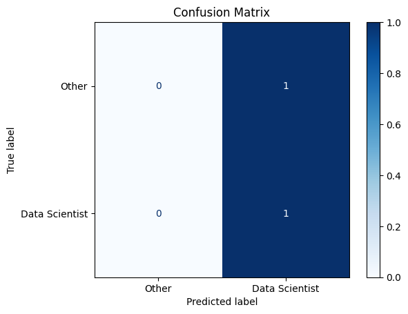

```python
# --- Imports ---
import numpy as np
import pandas as pd
import matplotlib.pyplot as plt
import seaborn as sns

from sklearn.feature_extraction.text import TfidfVectorizer
from sklearn.decomposition import TruncatedSVD
from sklearn.preprocessing import StandardScaler, OneHotEncoder
from sklearn.model_selection import train_test_split
from sklearn.metrics import confusion_matrix, accuracy_score, precision_score, recall_score, f1_score, roc_auc_score, ConfusionMatrixDisplay
from sklearn.utils import resample

import torch
import torch.nn as nn
import torch.optim as optim
from torch.utils.data import TensorDataset, DataLoader

# --- Load your dataset ---
# df = pd.read_csv("your_dataset.csv")  # Make sure you load the unclean dataset

# --- Target Column ---
# Create target: 1 if 'Data Scientist' in Job Title, else 0
df['is_data_scientist'] = df['Job Title'].str.contains('Data Scientist', case=False, na=False).astype(int)

# --- Balance classes if needed ---
df_majority = df[df.is_data_scientist==0]
df_minority = df[df.is_data_scientist==1]

if len(df_minority) == 0:
    raise ValueError("No Data Scientist entries found! Cannot train classifier.")

# Upsample minority
df_minority_upsampled = resample(df_minority,
                                 replace=True,
                                 n_samples=len(df_majority),
                                 random_state=42)

df_balanced = pd.concat([df_majority, df_minority_upsampled])
df_balanced = df_balanced.sample(frac=1, random_state=42).reset_index(drop=True)

# --- Feature Preparation ---
# Text
texts = df_balanced['Job Description'].fillna('').astype(str).values
tf = TfidfVectorizer(max_features=500, stop_words='english')
X_text_tfidf = tf.fit_transform(texts)
n_svd = min(50, X_text_tfidf.shape[1])
svd = TruncatedSVD(n_components=n_svd, random_state=42)
X_text = svd.fit_transform(X_text_tfidf)

# Numeric features
numeric_cols = [c for c in ['Salary','Rating','Founded'] if c in df_balanced.columns]
X_num = df_balanced[numeric_cols].values if len(numeric_cols) > 0 else np.zeros((df_balanced.shape[0],0))

# Categorical: Size + top 20 cities
cat_cols = []
if 'Size' in df_balanced.columns:
    cat_cols.append('Size')
if 'City' in df_balanced.columns:
    top_cities = df_balanced['City'].value_counts().index[:20].tolist()
    df_balanced['City_top'] = df_balanced['City'].apply(lambda x: x if x in top_cities else 'Other')
    cat_cols.append('City_top')

if cat_cols:
    ohe = OneHotEncoder(handle_unknown='ignore', sparse_output=False)
    X_cat = ohe.fit_transform(df_balanced[cat_cols])
else:
    X_cat = np.zeros((df_balanced.shape[0],0))

# Combine all features
X = np.hstack([X_num, X_cat, X_text])
y = df_balanced['is_data_scientist'].values

print('Feature matrix shape:', X.shape)
print('Class distribution:', np.unique(y, return_counts=True))

# --- Train-Test Split ---
X_train, X_test, y_train, y_test = train_test_split(
    X, y, test_size=0.2, random_state=42, stratify=y
)

# Scale numeric part
scaler = StandardScaler()
if len(numeric_cols) > 0:
    X_train[:, :len(numeric_cols)] = scaler.fit_transform(X_train[:, :len(numeric_cols)])
    X_test[:, :len(numeric_cols)] = scaler.transform(X_test[:, :len(numeric_cols)])

print('Training samples:', X_train.shape[0])

# --- Convert to PyTorch Tensors ---
X_train_tensor = torch.tensor(X_train, dtype=torch.float32)
X_test_tensor = torch.tensor(X_test, dtype=torch.float32)
y_train_tensor = torch.tensor(y_train.reshape(-1,1), dtype=torch.float32)
y_test_tensor = torch.tensor(y_test.reshape(-1,1), dtype=torch.float32)

train_dataset = TensorDataset(X_train_tensor, y_train_tensor)
train_loader = DataLoader(train_dataset, batch_size=16, shuffle=True)
test_dataset = TensorDataset(X_test_tensor, y_test_tensor)
test_loader = DataLoader(test_dataset, batch_size=32, shuffle=False)

# --- Define PyTorch Model ---
class SimpleMLP(nn.Module):
    def __init__(self, input_dim):
        super().__init__()
        self.net = nn.Sequential(
            nn.Linear(input_dim, 128),
            nn.ReLU(),
            nn.Dropout(0.3),
            nn.Linear(128,64),
            nn.ReLU(),
            nn.Dropout(0.2),
            nn.Linear(64,1),
            nn.Sigmoid()
        )
    def forward(self,x):
        return self.net(x)

device = torch.device('cuda' if torch.cuda.is_available() else 'cpu')
print('Using device:', device)
model = SimpleMLP(X_train.shape[1]).to(device)
criterion = nn.BCELoss()
optimizer = optim.Adam(model.parameters(), lr=1e-3)

# --- Training ---
epochs = 20
for epoch in range(1, epochs+1):
    model.train()
    total_loss = 0
    for xb, yb in train_loader:
        xb, yb = xb.to(device), yb.to(device)
        optimizer.zero_grad()
        out = model(xb)
        loss = criterion(out, yb)
        loss.backward()
        optimizer.step()
        total_loss += loss.item() * xb.size(0)
    print(f'Epoch {epoch}/{epochs}, Loss: {total_loss/len(train_loader.dataset):.4f}')

# --- Evaluation ---
model.eval()
y_true, y_proba = [], []
with torch.no_grad():
    for xb, yb in test_loader:
        xb = xb.to(device)
        out = model(xb).cpu().numpy().ravel()
        y_true.extend(yb.numpy().ravel().tolist())
        y_proba.extend(out.tolist())
y_true = np.array(y_true)
y_proba = np.array(y_proba)
y_pred = (y_proba >= 0.5).astype(int)

# --- Metrics ---
acc = accuracy_score(y_true, y_pred)
prec = precision_score(y_true, y_pred)
rec = recall_score(y_true, y_pred)
f1 = f1_score(y_true, y_pred)
auc = roc_auc_score(y_true, y_proba)

print("\nEvaluation Metrics:")
print(f"Accuracy: {acc:.3f}")
print(f"Precision: {prec:.3f}")
print(f"Recall: {rec:.3f}")
print(f"F1 Score: {f1:.3f}")
print(f"AUC: {auc:.3f}")

# --- Confusion Matrix ---
cm = confusion_matrix(y_true, y_pred, labels=[0,1])
disp = ConfusionMatrixDisplay(cm, display_labels=['Other','Data Scientist'])
disp.plot(cmap='Blues')
plt.title('Confusion Matrix')
plt.show()
```

## 3) Model A: Keras (TensorFlow) - simple MLP

Binary classification using a small feed-forward network.

```
Model: "sequential_4"
```

```
┏━━━━━━━━━━━━━━━━━━━━━━━━━━━━━━━━━━━━━━┳━━━━━━━━━━━━━━━━━━━━━━━━━━━━━┳━━━━━━━━━━━━━━━━━┓
┃ Layer (type)                         ┃ Output Shape                ┃         Param # ┃
┡━━━━━━━━━━━━━━━━━━━━━━━━━━━━━━━━━━━━━━╇━━━━━━━━━━━━━━━━━━━━━━━━━━━━━╇━━━━━━━━━━━━━━━━━┩
│ dense_12 (Dense)                     │ (None, 128)                 │           1,664 │
├──────────────────────────────────────┼─────────────────────────────┼─────────────────┤
│ dropout_8 (Dropout)                  │ (None, 128)                 │               0 │
├──────────────────────────────────────┼─────────────────────────────┼─────────────────┤
│ dense_13 (Dense)                     │ (None, 64)                  │           8,256 │
├──────────────────────────────────────┼─────────────────────────────┼─────────────────┤
│ dropout_9 (Dropout)                  │ (None, 64)                  │               0 │
├──────────────────────────────────────┼─────────────────────────────┼─────────────────┤
│ dense_14 (Dense)                     │ (None, 1)                   │              65 │
└──────────────────────────────────────┴─────────────────────────────┴─────────────────┘
```

```
 Total params: 9,985 (39.00 KB)
```

```
 Trainable params: 9,985 (39.00 KB)
```

```
 Non-trainable params: 0 (0.00 B)
```

```
1/1 ━━━━━━━━━━━━━━━━━━━━ 1s 987ms/step - accuracy: 1.0000 - loss: 0.6416 - val_accuracy: 0.0000e+00 - val_loss: 0.8243
1/1 ━━━━━━━━━━━━━━━━━━━━ 0s 85ms/step - accuracy: 0.6667 - loss: 0.7966 - val_accuracy: 0.0000e+00 - val_loss: 0.8253
1/1 ━━━━━━━━━━━━━━━━━━━━ 0s 83ms/step - accuracy: 1.0000 - loss: 0.5943 - val_accuracy: 0.0000e+00 - val_loss: 0.8256
1/1 ━━━━━━━━━━━━━━━━━━━━ 0s 75ms/step - accuracy: 1.0000 - loss: 0.6395 - val_accuracy: 0.0000e+00 - val_loss: 0.8244
1/1 ━━━━━━━━━━━━━━━━━━━━ 0s 75ms/step - accuracy: 0.3333 - loss: 0.7477 - val_accuracy: 0.0000e+00 - val_loss: 0.8209
1/1 ━━━━━━━━━━━━━━━━━━━━ 0s 75ms/step - accuracy: 1.0000 - loss: 0.5893 - val_accuracy: 0.0000e+00 - val_loss: 0.8153
1/1 ━━━━━━━━━━━━━━━━━━━━ 0s 75ms/step - accuracy: 0.3333 - loss: 0.6309 - val_accuracy: 0.0000e+00 - val_loss: 0.8107
1/1 ━━━━━━━━━━━━━━━━━━━━ 0s 79ms/step - accuracy: 1.0000 - loss: 0.5235 - val_accuracy: 0.0000e+00 - val_loss: 0.8072
1/1 ━━━━━━━━━━━━━━━━━━━━ 0s 75ms/step - accuracy: 1.0000 - loss: 0.5037 - val_accuracy: 0.0000e+00 - val_loss: 0.8041
1/1 ━━━━━━━━━━━━━━━━━━━━ 0s 81ms/step - accuracy: 1.0000 - loss: 0.5280 - val_accuracy: 0.0000e+00 - val_loss: 0.8018
1/1 ━━━━━━━━━━━━━━━━━━━━ 0s 77ms/step - accuracy: 1.0000 - loss: 0.5617 - val_accuracy: 0.0000e+00 - val_loss: 0.7989
1/1 ━━━━━━━━━━━━━━━━━━━━ 0s 77ms/step - accuracy: 0.6667 - loss: 0.5158 - val_accuracy: 0.0000e+00 - val_loss: 0.7957
1/1 ━━━━━━━━━━━━━━━━━━━━ 0s 76ms/step - accuracy: 1.0000 - loss: 0.4971 - val_accuracy: 0.0000e+00 - val_loss: 0.7925
1/1 ━━━━━━━━━━━━━━━━━━━━ 0s 75ms/step - accuracy: 1.0000 - loss: 0.5233 - val_accuracy: 0.0000e+00 - val_loss: 0.7888
1/1 ━━━━━━━━━━━━━━━━━━━━ 0s 75ms/step - accuracy: 1.0000 - loss: 0.4044 - val_accuracy: 0.0000e+00 - val_loss: 0.7863
1/1 ━━━━━━━━━━━━━━━━━━━━ 0s 97ms/step - accuracy: 1.0000 - loss: 0.4293 - val_accuracy: 0.0000e+00 - val_loss: 0.7838
1/1 ━━━━━━━━━━━━━━━━━━━━ 0s 84ms/step - accuracy: 1.0000 - loss: 0.4256 - val_accuracy: 0.0000e+00 - val_loss: 0.7810
1/1 ━━━━━━━━━━━━━━━━━━━━ 0s 87ms/step - accuracy: 1.0000 - loss: 0.4329 - val_accuracy: 0.0000e+00 - val_loss: 0.7776
1/1 ━━━━━━━━━━━━━━━━━━━━ 0s 75ms/step - accuracy: 1.0000 - loss: 0.3769 - val_accuracy: 0.0000e+00 - val_loss: 0.7747
1/1 ━━━━━━━━━━━━━━━━━━━━ 0s 76ms/step - accuracy: 1.0000 - loss: 0.3925 - val_accuracy: 0.0000e+00 - val_loss: 0.7716
1/1 ━━━━━━━━━━━━━━━━━━━━ 0s 76ms/step - accuracy: 1.0000 - loss: 0.3849 - val_accuracy: 0.0000e+00 - val_loss: 0.7680
1/1 ━━━━━━━━━━━━━━━━━━━━ 0s 75ms/step - accuracy: 1.0000 - loss: 0.3119 - val_accuracy: 0.0000e+00 - val_loss: 0.7634
1/1 ━━━━━━━━━━━━━━━━━━━━ 0s 78ms/step - accuracy: 1.0000 - loss: 0.3312 - val_accuracy: 0.0000e+00 - val_loss: 0.7580
1/1 ━━━━━━━━━━━━━━━━━━━━ 0s 78ms/step - accuracy: 1.0000 - loss: 0.3326 - val_accuracy: 0.0000e+00 - val_loss: 0.7523
1/1 ━━━━━━━━━━━━━━━━━━━━ 0s 81ms/step - accuracy: 1.0000 - loss: 0.3286 - val_accuracy: 0.0000e+00 - val_loss: 0.7469
1/1 ━━━━━━━━━━━━━━━━━━━━ 0s 85ms/step - accuracy: 1.0000 - loss: 0.2475 - val_accuracy: 0.0000e+00 - val_loss: 0.7410
1/1 ━━━━━━━━━━━━━━━━━━━━ 0s 78ms/step - accuracy: 1.0000 - loss: 0.3509 - val_accuracy: 0.0000e+00 - val_loss: 0.7348
1/1 ━━━━━━━━━━━━━━━━━━━━ 0s 75ms/step - accuracy: 1.0000 - loss: 0.3119 - val_accuracy: 0.0000e+00 - val_loss: 0.7274
1/1 ━━━━━━━━━━━━━━━━━━━━ 0s 75ms/step - accuracy: 1.0000 - loss: 0.3015 - val_accuracy: 0.0000e+00 - val_loss: 0.7196
1/1 ━━━━━━━━━━━━━━━━━━━━ 0s 74ms/step - accuracy: 1.0000 - loss: 0.3024 - val_accuracy: 0.0000e+00 - val_loss: 0.7114
1/1 ━━━━━━━━━━━━━━━━━━━━ 0s 74ms/step - accuracy: 1.0000 - loss: 0.2505 - val_accuracy: 0.0000e+00 - val_loss: 0.7029
1/1 ━━━━━━━━━━━━━━━━━━━━ 0s 74ms/step - accuracy: 1.0000 - loss: 0.2319 - val_accuracy: 0.0000e+00 - val_loss: 0.6940
1/1 ━━━━━━━━━━━━━━━━━━━━ 0s 103ms/step - accuracy: 1.0000 - loss: 0.2428 - val_accuracy: 1.0000 - val_loss: 0.6854
1/1 ━━━━━━━━━━━━━━━━━━━━ 0s 79ms/step - accuracy: 1.0000 - loss: 0.2249 - val_accuracy: 1.0000 - val_loss: 0.6771
```

[output cut: 18 more lines]

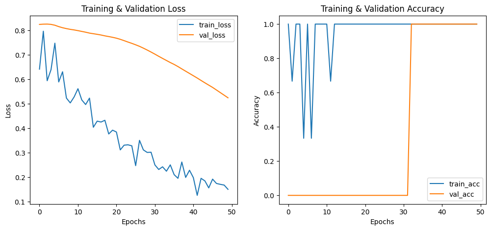

```python
import tensorflow as tf
from tensorflow.keras import layers, models, callbacks
from sklearn.preprocessing import StandardScaler
from sklearn.model_selection import train_test_split

# --- Use balanced dataset ---
X = np.hstack([X_num, X_cat, X_text])
y = df_balanced['is_data_scientist'].values

# --- Train-test split with stratification ---
X_train, X_test, y_train, y_test = train_test_split(
    X, y, test_size=0.2, random_state=42, stratify=y
)

# Scale numeric part
if len(numeric_cols) > 0:
    scaler = StandardScaler()
    X_train[:, :len(numeric_cols)] = scaler.fit_transform(X_train[:, :len(numeric_cols)])
    X_test[:, :len(numeric_cols)] = scaler.transform(X_test[:, :len(numeric_cols)])

# --- Keras Model ---
input_dim = X_train.shape[1]
model = models.Sequential([
    layers.Input(shape=(input_dim,)),
    layers.Dense(128, activation='relu'),
    layers.Dropout(0.3),
    layers.Dense(64, activation='relu'),
    layers.Dropout(0.2),
    layers.Dense(1, activation='sigmoid')
])

model.compile(optimizer='adam', loss='binary_crossentropy', metrics=['accuracy'])
model.summary()

# Early stopping
es = callbacks.EarlyStopping(monitor='val_loss', patience=5, restore_best_weights=True)

history = model.fit(
    X_train, y_train, validation_split=0.15,
    epochs=50, batch_size=32, callbacks=[es], verbose=1
)

# --- Predictions ---
keras_pred_proba = model.predict(X_test).ravel()
keras_pred = (keras_pred_proba >= 0.5).astype(int)

# --- Plots ---
plt.figure(figsize=(12,5))

# Loss
plt.subplot(1,2,1)
plt.plot(history.history['loss'], label='train_loss')
plt.plot(history.history['val_loss'], label='val_loss')
plt.xlabel('Epochs')
plt.ylabel('Loss')
plt.title('Training & Validation Loss')
plt.legend()

# Accuracy
plt.subplot(1,2,2)
plt.plot(history.history['accuracy'], label='train_acc')
plt.plot(history.history['val_accuracy'], label='val_acc')
plt.xlabel('Epochs')
plt.ylabel('Accuracy')
plt.title('Training & Validation Accuracy')
plt.legend()

plt.show()
```

## 4) Model B: PyTorch - simple MLP

We'll implement a small feed-forward network and a training loop.

```python
import torch
import torch.nn as nn
import torch.optim as optim
from torch.utils.data import TensorDataset, DataLoader
import numpy as np

# --- Device Setup ---
device = torch.device('cuda' if torch.cuda.is_available() else 'cpu')
print('Using device:', device)

# --- Define Model ---
class SimpleMLP(nn.Module):
    def __init__(self, input_dim):
        super().__init__()
        self.net = nn.Sequential(
            nn.Linear(input_dim, 128),
            nn.ReLU(),
            nn.Dropout(0.3),
            nn.Linear(128, 64),
            nn.ReLU(),
            nn.Dropout(0.2),
            nn.Linear(64, 1),
            nn.Sigmoid()
        )

    def forward(self, x):
        return self.net(x)

# --- Prepare Data ---
torch.manual_seed(42)

train_ds = TensorDataset(
    torch.tensor(X_train, dtype=torch.float32),
    torch.tensor(y_train, dtype=torch.float32)
)
test_ds = TensorDataset(
    torch.tensor(X_test, dtype=torch.float32),
    torch.tensor(y_test, dtype=torch.float32)
)

train_loader = DataLoader(train_ds, batch_size=32, shuffle=True)
test_loader = DataLoader(test_ds, batch_size=64, shuffle=False)

# --- Initialize Model, Loss, Optimizer ---
model_t = SimpleMLP(X_train.shape[1]).to(device)
criterion = nn.BCELoss()
optimizer = optim.Adam(model_t.parameters(), lr=1e-3)

# --- Training Function ---
def train_epoch(model, loader, opt, crit):
    model.train()
    running_loss = 0.0
    for xb, yb in loader:
        xb = xb.to(device)
        yb = yb.to(device).unsqueeze(1)
        opt.zero_grad()
        out = model(xb)
        loss = crit(out, yb)
        loss.backward()
        opt.step()
        running_loss += loss.item() * xb.size(0)
    return running_loss / len(loader.dataset)

# --- Evaluation Function ---
def evaluate(model, loader):
    model.eval()
    ys, yps = [], []
    with torch.no_grad():
        for xb, yb in loader:
            xb = xb.to(device)
            out = model(xb).cpu().numpy().ravel()
            ys.extend(yb.numpy().ravel().tolist())
            yps.extend(out.tolist())
    return np.array(ys), np.array(yps)

# --- Training Loop ---
best_loss = np.inf

for epoch in range(1, 51):
    loss = train_epoch(model_t, train_loader, optimizer, criterion)
    ys_val, yps_val = evaluate(model_t, test_loader)
    val_loss = criterion(
        torch.tensor(yps_val, dtype=torch.float32),
        torch.tensor(ys_val, dtype=torch.float32)
    ).item() if len(ys_val) > 0 else 0

    print(f'Epoch {epoch}: train_loss={loss:.4f}, val_loss={val_loss:.4f}')

    # Save best model
    if val_loss < best_loss:
        best_loss = val_loss
        torch.save(model_t.state_dict(), 'best_torch_model.pt')

# --- Load Best Model ---
model_t.load_state_dict(torch.load('best_torch_model.pt'))
y_true_t, y_proba_t = evaluate(model_t, test_loader)
torch_pred_proba = y_proba_t
torch_pred = (torch_pred_proba >= 0.5).astype(int)
```

```
Using device: cpu
Epoch 1: train_loss=0.6577, val_loss=0.5880
Epoch 2: train_loss=0.6835, val_loss=0.5941
Epoch 3: train_loss=0.6576, val_loss=0.5998
Epoch 4: train_loss=0.6556, val_loss=0.6047
Epoch 5: train_loss=0.6914, val_loss=0.6112
Epoch 6: train_loss=0.6660, val_loss=0.6175
Epoch 7: train_loss=0.6559, val_loss=0.6237
Epoch 8: train_loss=0.6224, val_loss=0.6299
Epoch 9: train_loss=0.6054, val_loss=0.6355
Epoch 10: train_loss=0.5979, val_loss=0.6416
Epoch 11: train_loss=0.5521, val_loss=0.6477
Epoch 12: train_loss=0.5731, val_loss=0.6540
Epoch 13: train_loss=0.5712, val_loss=0.6605
Epoch 14: train_loss=0.5284, val_loss=0.6673
Epoch 15: train_loss=0.5441, val_loss=0.6744
Epoch 16: train_loss=0.5474, val_loss=0.6814
Epoch 17: train_loss=0.5359, val_loss=0.6881
Epoch 18: train_loss=0.5078, val_loss=0.6949
Epoch 19: train_loss=0.4803, val_loss=0.7024
Epoch 20: train_loss=0.4691, val_loss=0.7115
Epoch 21: train_loss=0.4677, val_loss=0.7205
Epoch 22: train_loss=0.4563, val_loss=0.7304
Epoch 23: train_loss=0.4453, val_loss=0.7404
Epoch 24: train_loss=0.4477, val_loss=0.7507
Epoch 25: train_loss=0.4181, val_loss=0.7617
Epoch 26: train_loss=0.4165, val_loss=0.7733
Epoch 27: train_loss=0.4166, val_loss=0.7852
Epoch 28: train_loss=0.3765, val_loss=0.7972
Epoch 29: train_loss=0.3938, val_loss=0.8087
Epoch 30: train_loss=0.3374, val_loss=0.8213
Epoch 31: train_loss=0.3350, val_loss=0.8339
Epoch 32: train_loss=0.3465, val_loss=0.8470
Epoch 33: train_loss=0.3170, val_loss=0.8615
Epoch 34: train_loss=0.3227, val_loss=0.8760
Epoch 35: train_loss=0.3070, val_loss=0.8917
Epoch 36: train_loss=0.3062, val_loss=0.9081
Epoch 37: train_loss=0.3155, val_loss=0.9243
Epoch 38: train_loss=0.2404, val_loss=0.9403
Epoch 39: train_loss=0.2489, val_loss=0.9559
Epoch 40: train_loss=0.2305, val_loss=0.9718
Epoch 41: train_loss=0.2177, val_loss=0.9873
Epoch 42: train_loss=0.2359, val_loss=1.0042
Epoch 43: train_loss=0.1928, val_loss=1.0235
Epoch 44: train_loss=0.2337, val_loss=1.0438
Epoch 45: train_loss=0.1508, val_loss=1.0640
Epoch 46: train_loss=0.1897, val_loss=1.0854
Epoch 47: train_loss=0.1918, val_loss=1.1072
Epoch 48: train_loss=0.2200, val_loss=1.1284
Epoch 49: train_loss=0.1352, val_loss=1.1493
Epoch 50: train_loss=0.1459, val_loss=1.1708
```

## 5) Evaluation & Comparison

Compute accuracy, precision, recall, F1, ROC-AUC and show confusion matrices for both models.

```
Model comparison metrics:
```

|  | accuracy | precision | recall | f1 | auc |
| --- | --- | --- | --- | --- | --- |
| Keras_MLP | 1.0 | 1.0 | 1.0 | 1.0 | 1.0 |
| PyTorch_MLP | 1.0 | 0.0 | 0.0 | 0.0 | NaN |

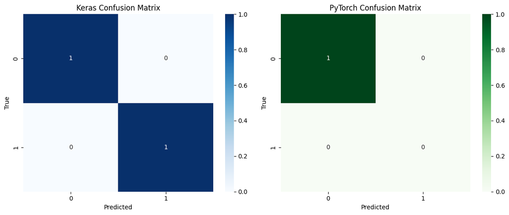

```python
import numpy as np
import pandas as pd
from sklearn.metrics import accuracy_score, precision_score, recall_score, f1_score, roc_auc_score, confusion_matrix
import matplotlib.pyplot as plt
import seaborn as sns

# --- Ensure y arrays are 1D ---
y_test = y_test.ravel() if y_test.ndim > 1 else y_test
y_true_t = y_true_t.ravel() if y_true_t.ndim > 1 else y_true_t

# --- Metrics computation function ---
def compute_metrics(y_true, y_pred, y_proba):
    return {
        'accuracy': accuracy_score(y_true, y_pred),
        'precision': precision_score(y_true, y_pred, zero_division=0),
        'recall': recall_score(y_true, y_pred, zero_division=0),
        'f1': f1_score(y_true, y_pred, zero_division=0),
        'auc': roc_auc_score(y_true, y_proba) if len(np.unique(y_true)) > 1 else np.nan
    }

# --- Optional safeguard: ensure target exists ---
if 'is_data_scientist' not in df_balanced.columns:
    df_balanced['is_data_scientist'] = (df_balanced['Job Title']
                                        .str.contains('Data Scientist', case=False, na=False)).astype(int)

# --- Compute metrics for both models ---
keras_metrics = compute_metrics(y_test, keras_pred, keras_pred_proba)
torch_metrics = compute_metrics(y_true_t, torch_pred, torch_pred_proba)

# --- Comparison table ---
results = pd.DataFrame([keras_metrics, torch_metrics], index=['Keras_MLP','PyTorch_MLP'])
results = results.round(3)
print('Model comparison metrics:')
display(results)

# --- Confusion matrices ---
fig, axes = plt.subplots(1,2, figsize=(12,5))

cmk = confusion_matrix(y_test, keras_pred, labels=[0,1])
cmt = confusion_matrix(y_true_t, torch_pred, labels=[0,1])

sns.heatmap(cmk, annot=True, fmt='d', ax=axes[0], cmap='Blues')
axes[0].set_title('Keras Confusion Matrix')
axes[0].set_xlabel('Predicted')
axes[0].set_ylabel('True')

sns.heatmap(cmt, annot=True, fmt='d', ax=axes[1], cmap='Greens')
axes[1].set_title('PyTorch Confusion Matrix')
axes[1].set_xlabel('Predicted')
axes[1].set_ylabel('True')

plt.tight_layout()
plt.show()
```

## 6) Discussion & Next steps

- The simple pipeline above demonstrates cleaning, feature engineering, and model training using **Keras** and **PyTorch**.
- For improved performance consider:
  - More advanced text models (transformers / fine-tuning)
  - Better handling of class imbalance (if present) via resampling or weighted loss
  - Hyperparameter tuning with cross-validation
  - More careful imputation and feature selection

### Deliverables

- This notebook (HTML export) and `Cleaned_DS_jobs.csv` should be submitted together in Canvas as required by the assignment brief.